# Introduction to Python

Python is a high-level, interpreted programming language known for its simplicity and readability. It is widely used in various domains, including web development, data analysis, text analysis, artificial intelligence, scientific computing, and more. Python's versatility and extensive library ecosystem make it a popular choice for both beginners and experienced developers.

## Example: Hello World in Python

```
print("Hello, World!")
```

## Applications of Python

| **Category** | **Libraries/Tools** | **Example Use Case** |
| --- | --- | --- |
| Web Development | Django, Flask | Build a blog, dashboard, or interactive visualization |
| Data Science | pandas, NumPy, Matplotlib | Analyze, clean, and visualize quanitative or qualitative data |
| Automation | os, shutil, sched | Rename a batch of files |
| Text Analyis | spaCy, NLTK | Sentiment analysis on reviews |
| Mapping | GeoPandas, Folium, geopy | Plot locations on an interactive map |
| Data Management | pandas, `csv`, `xlm`, `json` | Clean and standardize metadata for a digital collection |
| Webscraping | BeautifulSoup, Scrapy | Collect daily weather data |
| Machine Learning | scikit-learn, TensorFlow | Classify emails as spam |
| Data Processing/Cleaning | pandas, regex, `csv` | Clean historical census data for analysis |
| Education | Jupyter | Provide introductory material in an easy format |

## Libraries

Libraries are collections of code, that you can essentially "check-out" to use. Once you import the library, you call different modules or functions within that library to perform specific tasks.

[figure not shown]

```python
## Here we're going to import a couple of libraries that we will use in our codes.
## Notice that we are using the "as" keyword to give aliases to the libraries - this is a common practice to make the code cleaner and easier to read.
import pandas as pd
import numpy as np
import matplotlib.pyplot as plt
```

## Data Types

Data types are the kinds of values you can use in Python. Every value in Python has a type and unlike other many other languages you do not have to explicitly set these types. However because of that you have to be diligent to keep track of the types as you go.

Each type will have it's own set of functions and expressions that can performed.

### Basic Data Types

| Type | Example | Description |
| --- | --- | --- |
| `int` | 42, -2, 3244235 | Whole numbers (positive or negative) |
| `float` | 3.193727, 0.55, -2423.34243 | Decimal numbers |
| `str` | "hello", "hello, world", "h" | Text (string of characters) |
| `bool` | True, False | Boolean values (logic, conditionals) |

Example of discrete and continuous observations.

Discrete:

[figure not shown]

Continuous:

[figure not shown]

```python
## Now let's go through some examples of these data types

## number of penguins - ints
18
10
324234

num_of_penguins = 18

num_of_penguins_on_island_one = 10 + 18 + 22
print(num_of_penguins_on_island_one)
```

```
50
```

```python
##  bill sizes and averages - floats
average_penguins_per_species_island_one = num_of_penguins_on_island_one / 3.0
print(average_penguins_per_species_island_one)

12.2

bill_length_mm = 12.2
bill_depth_mm = 5.1
```

```
16.666666666666668
```

We can also do other types of mathematics:

| Operation | Symbol | Example | Output |
| --- | --- | --- | --- |
| Addition | `+` | `1 + 1` | `2` |
| Subtraction | `-` | `2 - 1` | `1` |
| Multiplication | `*` | `2 * 2` | `4` |
| Division | `/` | `3 / 1` | `3` |
| Division (floor) | `//` | `10 // 3` | `3` |
| Remainder | `%` | `10 % 3` | `1` |
| Exponent | `**` | `3 ** 2` | `9` |

**Try it Yourself**: Let’s combine what we know about variable names, expressions, and int/floats to calculate the adjusted body mass of a penguin after a simulated feeding period. Suppose you observe a penguin that weighs 4,200 grams. Based on typical feeding patterns, you expect the penguin to gain 8% of its body mass over a week. After gaining weight, the penguin is tagged, and the tagging equipment adds an additional 150 grams.

First, calculate the weight gain. Then add the equipment weight to get the total adjusted body mass.

```python
penguin_weight = 4200
weight_gain = 4200 * 0.08
equipment_weight = 150
adjusted_body_mass = penguin_weight + weight_gain + equipment_weight

print(adjusted_body_mass, weight_gain)
print("Adjusted body mass:", adjusted_body_mass, "grams or ", adjusted_body_mass / 1000, "kg")
```

```
4686.0 336.0
Adjusted body mass: 4686.0 grams or  4.686 kg
```

```python
num_penguins = 15  # number of penguins in the colony
```

```python
## We can also convert numbers to strings
num_penguins_str = str(num_penguins)
print(num_penguins_str, type(num_penguins_str))
print(num_penguins, type(num_penguins))
```

```
15 <class 'str'>
15 <class 'int'>
```

```python
## Now let's look more at strings
```

```python
## we can do a couple different things with strings, like finding their length
species = "gentoo"
species_length = len(species)
print(species_length)
```

```
6
```

```python
## or we can add strings together
region = "Antarctica"
island = "Dream"
full_location = region + " - " + island
full_title = "The " + species + " penguin from " + full_location
print(full_title)
```

```
The gentoo penguin from Antarctica - Dream
```

```python
## we can also strip characters from strings, select specific words or characters, and convert them to uppercase or lowercase
species = "  Gentoo Penguin  x"
stripped_species = species.strip('x').strip()
print(species)
print(stripped_species)
```

```
  Gentoo Penguin  x
Gentoo Penguin
```

```python
last_word = full_location.split()[-1]
print(last_word)

uppercase_location = full_location.upper()
print(uppercase_location)

lowercase_location = full_location.lower()
print(lowercase_location)
```

```
Dream
ANTARCTICA - DREAM
antarctica - dream
```

### Collection Data Types

| Type | Example | Description |
| --- | --- | --- |
| `list` | `[1, 2, 3]` or `[99, 'hello', False]` | Ordered, changeable sequence |
| `dict` | `{"key":"value"}` or `{"Ada":['Librarian', 42, "Carpenter"]}` | Key-value pairs |
| `tuple` | `(1, 2, 3, 3)` | Ordered, unchangeable sequence |
| `set` | `set(1, 2, 3)` | Unordered collection of unique values |

```python
## Now let's look at lists, which are a way to store multiple items in a single variable
islands = ["Torgersen",
           "Biscoe",
           "Dream",
           "Torgersen",
           "Anvers"]
print(islands)
print(type(islands))
```

```
['Torgersen', 'Biscoe', 'Dream', 'Torgersen', 'Anvers']
<class 'list'>
```

```python
## we can select specific items from a list using their index (Python always starts counting at 0)
first_island = islands[0]
print(first_island)
```

```
Torgersen
```

```python
## an easy way to get the last item is to use a negative index
last_island = islands[-1]
print(last_island)
```

```
Anvers
```

```python
## we can also add items to a list using append()
islands.append("New Island")
print(islands)
```

```
['Torgersen', 'Biscoe', 'Dream', 'Torgersen', 'Anvers', 'New Island']
```

```python
## or we can remove items using remove()
islands.remove("Torgersen")
print(islands)
```

```
['Biscoe', 'Dream', 'Torgersen', 'Anvers', 'New Island']
```

```python
## we can also sort lists
islands.sort()
print(islands)
```

```
['Anvers', 'Biscoe', 'Dream', 'New Island', 'Torgersen']
```

```python
## now let's look at dictionaries, which are a way to store key-value pairs

penguin_info = {
    "id": 1,
    "species": "Gentoo",
    "island": "Biscoe",
    "weight": 4.5,
    "bill_length": 0.2,
    "bill_depth": 0.05

}
print(penguin_info)

print(type(penguin_info))
```

```
{'id': 1, 'species': 'Gentoo', 'island': 'Biscoe', 'weight': 4.5, 'bill_length': 0.2, 'bill_depth': 0.05}
<class 'dict'>
```

```python
## we can access specific values in a dictionary using their keys
species = penguin_info["species"]
print(species)
```

```
Gentoo
```

```python
## we can also add new key-value pairs to a dictionary
penguin_info["age"] = 3
print(penguin_info)
```

```
{'id': 1, 'species': 'Gentoo', 'island': 'Biscoe', 'weight': 4.5, 'bill_length': 0.2, 'bill_depth': 0.05, 'age': 3}
```

```python
## or we can remove key-value pairs using the del keyword
del penguin_info["weight"]
print(penguin_info)
```

```
{'id': 1, 'species': 'Gentoo', 'island': 'Biscoe', 'bill_length': 0.2, 'bill_depth': 0.05, 'age': 3}
```

```python
## we can have dictionaries within dictionaries, which is useful for more complex data structures
summer_population = {
    1: {
        "id": 1,
        "species": "Gentoo",
        "island": "Biscoe",
        "weight": 4.5,
        "bill_length": 0.2,
        "bill_depth": 0.05
    },
    22: {
        "id": 22,
        "species": "Adelie",
        "island": "Torgersen",
        "weight": 3.8,
        "bill_length": 0.18,
        "bill_depth": 0.04
    }
}
print(summer_population)
```

```
{1: {'id': 1, 'species': 'Gentoo', 'island': 'Biscoe', 'weight': 4.5, 'bill_length': 0.2, 'bill_depth': 0.05}, 22: {'id': 22, 'species': 'Adelie', 'island': 'Torgersen', 'weight': 3.8, 'bill_length': 0.18, 'bill_depth': 0.04}}
```

```python
## we can access specific books in the collection using their keys
penguin_id = 22
penguin_details = summer_population[penguin_id]
print(penguin_details)

## we can also access specific values within the nested dictionary
penguin_weight = penguin_details["weight"]
print(penguin_weight)

average_bill_length = summer_population[1]["bill_length"] + summer_population[22]["bill_length"] / 2
print(average_bill_length)
```

```
{'id': 22, 'species': 'Adelie', 'island': 'Torgersen', 'weight': 3.8, 'bill_length': 0.18, 'bill_depth': 0.04}
3.8
0.29000000000000004
```

## Loops and Conditionals

### Conditionals or Comparisons

Sometimes we want to be able to compare different variables or expressions. This could be to find matching amounts/text or perhaps you want to identify when a specifc number rises above a certain threshold. We can do this through using comparison statements.

Reminder: Booleans - represent either True or False often in logic or conditional statements

```python
## let's look at some examples of using conditional statements

penguin_1_weight = summer_population[1]["weight"]
penguin_22_weight = summer_population[22]["weight"]


penguin_1_weight > penguin_22_weight

penguin_1_weight == penguin_22_weight
```

```
False
```

### Methods of comparison

| Comparison | Operator |
| --- | --- |
| Less than | `<` |
| Greater than | `>` |
| Less than or equal to | `<=` |
| Greater than or equal to | `>=` |
| Equal | `==` |
| Not equal | `!=` |

```python
## We can combine if statements with conditional operators to help move through the code

if penguin_1_weight > penguin_22_weight:
    print("Penguin 1 is heavier than Penguin 22")
elif penguin_1_weight < penguin_22_weight:
    print("Penguin 1 is lighter than Penguin 22")
else:
    print("Penguin 1 and Penguin 22 have the same weight")
```

```
Penguin 1 is heavier than Penguin 22
```

```python
## we can also combine multiple conditions together using keywords like 'and', 'or', and 'not'
if penguin_1_weight > 3.7 and penguin_22_weight > 3.7:
    print("Both penguins are heavier than the average weight.")
else:
    print("At least one penguin is not heavier than the average weight.")
```

```
Both penguins are heavier than the average weight.
```

### Loops (Automation)

Sometimes we will want to repeat the exact same task again and again. In python, loops allow us to create this type of automations to repeat tasks efficiently. The most common types of loops are using *for* and *while*. A for loop is often used to iterate over a sequence such as a list executing the same code for each element in the list. A while loop continues to run as long as a specified condition remains true.

```python
## The final piece is to look at loops which allows us to iterate over our collection data types

## Let's start with a simple for loop to iterate over a list of islands
for island in islands:
    print("Island:", island)
```

```
Island: Anvers
Island: Biscoe
Island: Dream
Island: New Island
Island: Torgersen
```

```python
## we can also use the range function to iterate over a list by the index values
for i in range(len(islands)):
    print(f"Island {i + 1}: {islands[i]}")
```

```
Island 1: Anvers
Island 2: Biscoe
Island 3: Dream
Island 4: New Island
Island 5: Torgersen
```

```python
## now let's combine loops and conditional statements
for penguin_id, details in summer_population.items():
    if details["weight"] > 3.5:
        print(f"Penguin {penguin_id} is larger than 3.5 kg and was found in {details['island']}")
```

```
Penguin 1 is larger than 3.5 kg and was found in Biscoe
Penguin 22 is larger than 3.5 kg and was found in Torgersen
```

## Tables

When working with data in Python, we often organize it in a table with rows and columns. The most powerful tool for working with tables is a library called `pandas` which makes it easy to load data from csv and Excel files, view and explore datasets, filter and clean data, calculate statistics, and prepare data for visualization.

Tables are stored in an object called a DataFrame.

```python
## We're going to start by using Pandas to read in a CSV file that contains information about the Palmer Penguin dataset.
from palmerpenguins import load_penguins
penguins = load_penguins()  ## https://github.com/mcnakhaee/palmerpenguins
penguins

## normally we can load a CSV file using Pandas like this:
# df = pd.read_csv('path_to_your_file.csv')
```

|  | species | island | bill_length_mm | bill_depth_mm | flipper_length_mm | body_mass_g | sex | year |
| --- | --- | --- | --- | --- | --- | --- | --- | --- |
| 0 | Adelie | Torgersen | 39.1 | 18.7 | 181.0 | 3750.0 | male | 2007 |
| 1 | Adelie | Torgersen | 39.5 | 17.4 | 186.0 | 3800.0 | female | 2007 |
| 2 | Adelie | Torgersen | 40.3 | 18.0 | 195.0 | 3250.0 | female | 2007 |
| 3 | Adelie | Torgersen | NaN | NaN | NaN | NaN | NaN | 2007 |
| 4 | Adelie | Torgersen | 36.7 | 19.3 | 193.0 | 3450.0 | female | 2007 |
| ... | ... | ... | ... | ... | ... | ... | ... | ... |
| 339 | Chinstrap | Dream | 55.8 | 19.8 | 207.0 | 4000.0 | male | 2009 |
| 340 | Chinstrap | Dream | 43.5 | 18.1 | 202.0 | 3400.0 | female | 2009 |
| 341 | Chinstrap | Dream | 49.6 | 18.2 | 193.0 | 3775.0 | male | 2009 |
| 342 | Chinstrap | Dream | 50.8 | 19.0 | 210.0 | 4100.0 | male | 2009 |
| 343 | Chinstrap | Dream | 50.2 | 18.7 | 198.0 | 3775.0 | female | 2009 |

344 rows × 8 columns

```python
## You can double click on the table output above to hide or collapse it.
## Notice how the table hides the middle rows and columns to make it easier to read?
## Let's change that so we can see all the columns and rows in the DataFrame.
with pd.option_context('display.max_columns', None, 'display.max_rows', None):
    display(penguins)
```

|  | species | island | bill_length_mm | bill_depth_mm | flipper_length_mm | body_mass_g | sex | year |
| --- | --- | --- | --- | --- | --- | --- | --- | --- |
| 0 | Adelie | Torgersen | 39.1 | 18.7 | 181.0 | 3750.0 | male | 2007 |
| 1 | Adelie | Torgersen | 39.5 | 17.4 | 186.0 | 3800.0 | female | 2007 |
| 2 | Adelie | Torgersen | 40.3 | 18.0 | 195.0 | 3250.0 | female | 2007 |
| 3 | Adelie | Torgersen | NaN | NaN | NaN | NaN | NaN | 2007 |
| 4 | Adelie | Torgersen | 36.7 | 19.3 | 193.0 | 3450.0 | female | 2007 |
| 5 | Adelie | Torgersen | 39.3 | 20.6 | 190.0 | 3650.0 | male | 2007 |
| 6 | Adelie | Torgersen | 38.9 | 17.8 | 181.0 | 3625.0 | female | 2007 |
| 7 | Adelie | Torgersen | 39.2 | 19.6 | 195.0 | 4675.0 | male | 2007 |
| 8 | Adelie | Torgersen | 34.1 | 18.1 | 193.0 | 3475.0 | NaN | 2007 |
| 9 | Adelie | Torgersen | 42.0 | 20.2 | 190.0 | 4250.0 | NaN | 2007 |
| 10 | Adelie | Torgersen | 37.8 | 17.1 | 186.0 | 3300.0 | NaN | 2007 |
| 11 | Adelie | Torgersen | 37.8 | 17.3 | 180.0 | 3700.0 | NaN | 2007 |
| 12 | Adelie | Torgersen | 41.1 | 17.6 | 182.0 | 3200.0 | female | 2007 |
| 13 | Adelie | Torgersen | 38.6 | 21.2 | 191.0 | 3800.0 | male | 2007 |
| 14 | Adelie | Torgersen | 34.6 | 21.1 | 198.0 | 4400.0 | male | 2007 |
| 15 | Adelie | Torgersen | 36.6 | 17.8 | 185.0 | 3700.0 | female | 2007 |
| 16 | Adelie | Torgersen | 38.7 | 19.0 | 195.0 | 3450.0 | female | 2007 |
| 17 | Adelie | Torgersen | 42.5 | 20.7 | 197.0 | 4500.0 | male | 2007 |
| 18 | Adelie | Torgersen | 34.4 | 18.4 | 184.0 | 3325.0 | female | 2007 |
| 19 | Adelie | Torgersen | 46.0 | 21.5 | 194.0 | 4200.0 | male | 2007 |
| 20 | Adelie | Biscoe | 37.8 | 18.3 | 174.0 | 3400.0 | female | 2007 |
| 21 | Adelie | Biscoe | 37.7 | 18.7 | 180.0 | 3600.0 | male | 2007 |
| 22 | Adelie | Biscoe | 35.9 | 19.2 | 189.0 | 3800.0 | female | 2007 |
| 23 | Adelie | Biscoe | 38.2 | 18.1 | 185.0 | 3950.0 | male | 2007 |
| 24 | Adelie | Biscoe | 38.8 | 17.2 | 180.0 | 3800.0 | male | 2007 |
| 25 | Adelie | Biscoe | 35.3 | 18.9 | 187.0 | 3800.0 | female | 2007 |
| 26 | Adelie | Biscoe | 40.6 | 18.6 | 183.0 | 3550.0 | male | 2007 |
| 27 | Adelie | Biscoe | 40.5 | 17.9 | 187.0 | 3200.0 | female | 2007 |
| 28 | Adelie | Biscoe | 37.9 | 18.6 | 172.0 | 3150.0 | female | 2007 |
| 29 | Adelie | Biscoe | 40.5 | 18.9 | 180.0 | 3950.0 | male | 2007 |

[output cut: 314 more lines]

```python
## we can do some basic analyis on the dataset
print(penguins.shape)  # Get the number of rows and columns in the DataFrame
print(penguins.info())  # Get information about the DataFrame, including data types and non-null counts
```

```
(344, 8)
<class 'pandas.core.frame.DataFrame'>
RangeIndex: 344 entries, 0 to 343
Data columns (total 8 columns):
 #   Column             Non-Null Count  Dtype
---  ------             --------------  -----
 0   species            344 non-null    object
 1   island             344 non-null    object
 2   bill_length_mm     342 non-null    float64
 3   bill_depth_mm      342 non-null    float64
 4   flipper_length_mm  342 non-null    float64
 5   body_mass_g        342 non-null    float64
 6   sex                333 non-null    object
 7   year               344 non-null    int64
dtypes: float64(4), int64(1), object(3)
memory usage: 21.6+ KB
None
```

```python
print(penguins.describe())  # Get summary statistics for numerical columns
```

```
       bill_length_mm  bill_depth_mm  flipper_length_mm  body_mass_g  \
count      342.000000     342.000000         342.000000   342.000000
mean        43.921930      17.151170         200.915205  4201.754386
std          5.459584       1.974793          14.061714   801.954536
min         32.100000      13.100000         172.000000  2700.000000
25%         39.225000      15.600000         190.000000  3550.000000
50%         44.450000      17.300000         197.000000  4050.000000
75%         48.500000      18.700000         213.000000  4750.000000
max         59.600000      21.500000         231.000000  6300.000000

              year
count   344.000000
mean   2008.029070
std       0.818356
min    2007.000000
25%    2007.000000
50%    2008.000000
75%    2009.000000
max    2009.000000
```

```python
penguins.columns
```

```
Index(['species', 'island', 'bill_length_mm', 'bill_depth_mm',
       'flipper_length_mm', 'body_mass_g', 'sex', 'year'],
      dtype='object')
```

```python
## We can select specific columns from the DataFrame by using their names
penguins['species']  # Select a single column by its name

## We can also select multiple columns by passing a list of column names
penguins[['species', 'island', 'year']]
```

|  | species | island | year |
| --- | --- | --- | --- |
| 0 | Adelie | Torgersen | 2007 |
| 1 | Adelie | Torgersen | 2007 |
| 2 | Adelie | Torgersen | 2007 |
| 3 | Adelie | Torgersen | 2007 |
| 4 | Adelie | Torgersen | 2007 |
| ... | ... | ... | ... |
| 339 | Chinstrap | Dream | 2009 |
| 340 | Chinstrap | Dream | 2009 |
| 341 | Chinstrap | Dream | 2009 |
| 342 | Chinstrap | Dream | 2009 |
| 343 | Chinstrap | Dream | 2009 |

344 rows × 3 columns

```python
## We can filter the DataFrame based on specific conditions
filtered_df = penguins[penguins['body_mass_g'] > 3500]  # Select rows where the body mass is greater than 3.5 kg
print(filtered_df)
```

```
       species     island  bill_length_mm  bill_depth_mm  flipper_length_mm  \
0       Adelie  Torgersen            39.1           18.7              181.0
1       Adelie  Torgersen            39.5           17.4              186.0
5       Adelie  Torgersen            39.3           20.6              190.0
6       Adelie  Torgersen            38.9           17.8              181.0
7       Adelie  Torgersen            39.2           19.6              195.0
..         ...        ...             ...            ...                ...
338  Chinstrap      Dream            45.7           17.0              195.0
339  Chinstrap      Dream            55.8           19.8              207.0
341  Chinstrap      Dream            49.6           18.2              193.0
342  Chinstrap      Dream            50.8           19.0              210.0
343  Chinstrap      Dream            50.2           18.7              198.0

     body_mass_g     sex  year
0         3750.0    male  2007
1         3800.0  female  2007
5         3650.0    male  2007
6         3625.0  female  2007
7         4675.0    male  2007
..           ...     ...   ...
338       3650.0  female  2009
339       4000.0    male  2009
341       3775.0    male  2009
342       4100.0    male  2009
343       3775.0  female  2009

[264 rows x 8 columns]
```

```python
## We can calculate statistics on specific columns
average_bill_length = penguins['bill_length_mm'].mean()  # Calculate the average bill length
print(average_bill_length)
```

```
43.9219298245614
```

**Try It Yourself**: Select a column and try to find out some basic summary statistics such as the minimum, maximum, median, mean, and mode values.

## Visualization

Now let's think about how we might continue to explore this dataset using visualizations. We're going to be using a combination of pandas' built-in plotting functions and the matplotlib library.

Matplotlib is one of the most powerful and widely used libraries for creating visualizations in Python. While other libraries such as seaborn and plotly offer stylish and interactive plots with less code, matplotlib gives you the ability to have fine-grained control over every aspect of a figure.

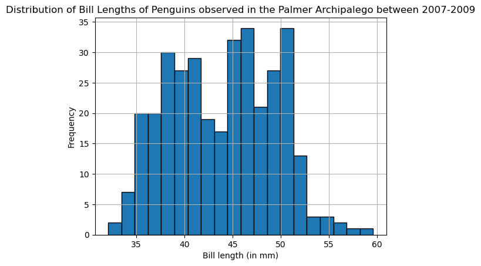

```python
## Example 1: Histograms - Used for showing the distribution of single numerical variable

penguins.hist('bill_length_mm', bins=20, edgecolor='black')  ## here is where we actually create the histogram
plt.xlabel('Bill length (in mm)')  ## here we label the x-axis
plt.ylabel('Frequency')  ## here we label the y-axis
plt.title('Distribution of Bill Lengths of Penguins observed in the Palmer Archipalego between 2007-2009')  ## here we give it a title
```

Now let's look at a more complicated example. We have several columns that are categorical. We might want to look at the comparison between these columns such as the example below where we examine the difference in weights between different species.

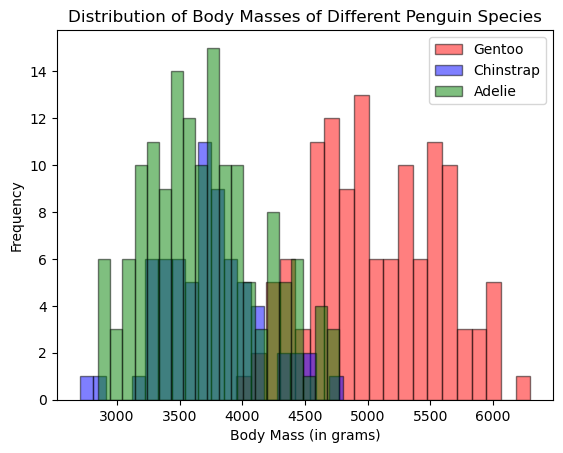

```python
gentoo = penguins[penguins['species'] == 'Gentoo']
chinstrap = penguins[penguins['species'] == 'Chinstrap']
adelie = penguins[penguins['species'] == 'Adelie']


plt.hist(gentoo['body_mass_g'], bins=20, edgecolor='black', alpha=0.5, label='Gentoo', color = 'red')
plt.hist(chinstrap['body_mass_g'], bins=20, edgecolor='black', alpha=0.5, label='Chinstrap', color = 'blue')
plt.hist(adelie['body_mass_g'], bins=20, edgecolor='black', alpha=0.5, label='Adelie', color = 'green')
plt.legend()
plt.xlabel('Body Mass (in grams)')
plt.ylabel('Frequency')
plt.title('Distribution of Body Masses of Different Penguin Species')
plt.show()
plt.clf()
```

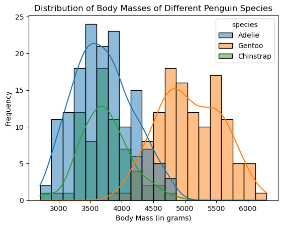

```python
## we can also do this using seaborn, which is a library built on top of matplotlib that makes it easier to create complex visualizations
import seaborn as sns
sns.histplot(data=penguins, x='body_mass_g', hue = 'species', bins=20, kde=True, color='blue', edgecolor='black')
plt.xlabel('Body Mass (in grams)')
plt.ylabel('Frequency')
plt.title('Distribution of Body Masses of Different Penguin Species')
plt.show()
```

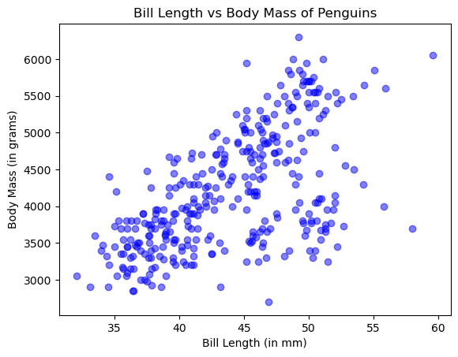

```python
## Example 2: Scatter Plots - Used for showing the relationship between two numerical variables

plt.scatter(penguins['bill_length_mm'], penguins['body_mass_g'], alpha=0.5, color='blue')
plt.xlabel('Bill Length (in mm)')
plt.ylabel('Body Mass (in grams)')
plt.title('Bill Length vs Body Mass of Penguins')
plt.show()
```

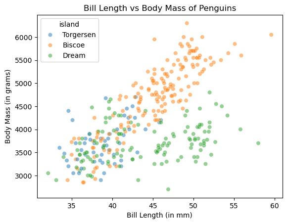

```python
sns.scatterplot(data=penguins, x='bill_length_mm', y='body_mass_g', hue='island', alpha=0.5)
plt.xlabel('Bill Length (in mm)')
plt.ylabel('Body Mass (in grams)')
plt.title('Bill Length vs Body Mass of Penguins')
plt.show()
```

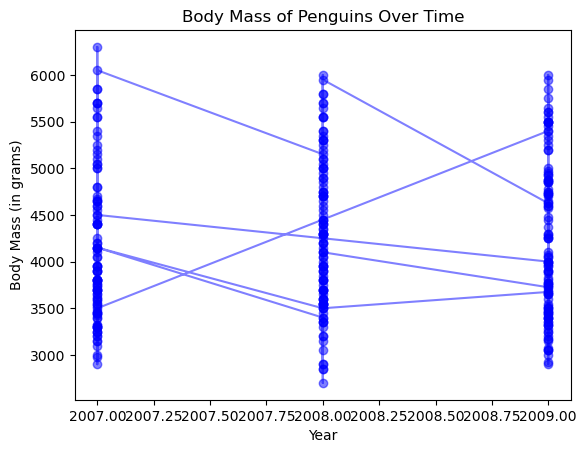

```python
## Example 3: Line Plots - Used for showing trends over time or ordered categories

plt.plot(penguins['year'], penguins['body_mass_g'], marker='o', linestyle='-', color='blue', alpha=0.5)
plt.xlabel('Year')
plt.ylabel('Body Mass (in grams)')
plt.title('Body Mass of Penguins Over Time')
plt.show()
```

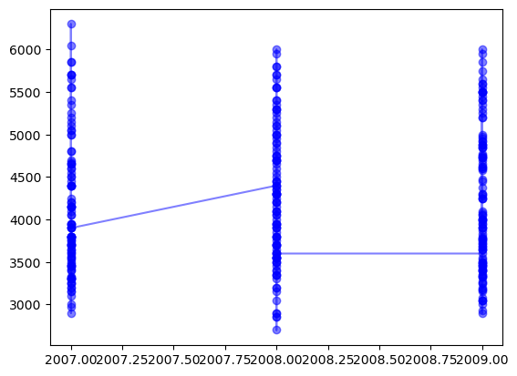

```python
## we can see that this doesn't quite work as expected because the publication years are not sorted and are not unique
## so let's try to fix that
sorted_df = penguins.sort_values(by='year')  # Sort the DataFrame by publication year
plt.plot(sorted_df['year'], sorted_df['body_mass_g'], marker='o', linestyle='-', color='blue', alpha=0.5)
plt.show()
```

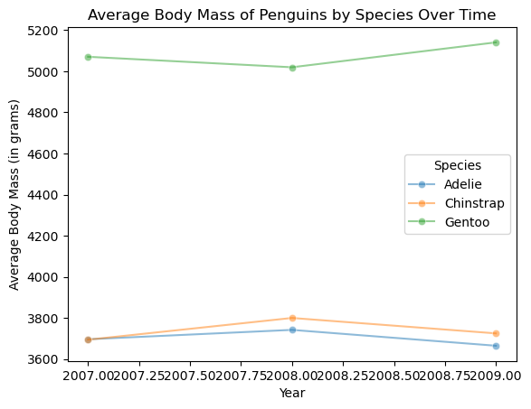

```python
## still not quite what we want so let's group the data by year and get an average
grouped_df = penguins.groupby(['species', 'year'])['body_mass_g'].mean().reset_index()  # Group by species and year, then calculate the mean body mass

sns.lineplot(data=grouped_df, x='year', y='body_mass_g', hue='species', marker='o', alpha=0.5)
plt.xlabel('Year')
plt.ylabel('Average Body Mass (in grams)')
plt.title('Average Body Mass of Penguins by Species Over Time')
plt.legend(title='Species')
plt.show()
```

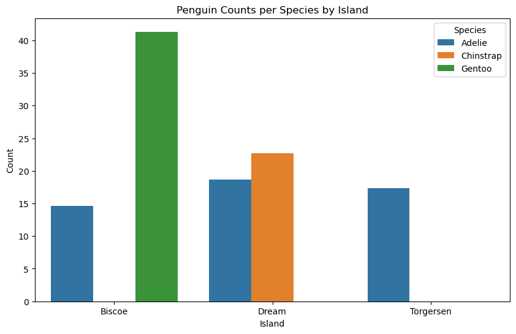

```python
## Example 4: Bar Plots - Used for comparing categorical data

counts = penguins.groupby(['year', 'species', 'island']).size().reset_index(name='count')

# Plot as a bar graph
plt.figure(figsize=(10, 6))
sns.barplot(data=counts, x='island', y='count', hue='species', ci=None)
plt.title('Penguin Counts per Species by Island')
plt.ylabel('Count')
plt.xlabel('Island')
plt.legend(title='Species')
plt.show()
```

**Try it Yourself**: Pick a column or a series of columns to explore. Try to visualize your selected data - is there any obstacles you encountered? Is the data in a form that you have to alter or manipulate or filter?

## Application: Machine Learning

Now let's put everything together to build a simple machine learning model. Machine learning is a way to teach computers to recognize patterns and make predictions based on data. This is kind of like giving them examples and asking them to guess the answer for new cases.

We're going to use supervised learning, where we give the model both the input (penguin measurements) and the correct answer (the species). The model will learn from this and try to predict species for new penguins it hasn't seen before.

Here are the basic steps:

1. Load Data - We did this above using `palmerpenguins`
2. Clean Data - We want to remove missing values.
3. Choose features and labels - We want to identify what attributes we want to use to do the predicts and what are the correct labels.
4. Split into traning and testing data - We split our dataset into what we will use to train and what we will use to evaluate (test).
5. Train the model - Using the training data subset, the machine learning algorithm will look for patterns in the data.
6. Evaluate the model - We can see how accurate the model is using the test set where we know the correct answers.
7. Predict labels for new data - Using the trained model, we can predict the labels for new data.

```python
from sklearn.model_selection import train_test_split
from sklearn.ensemble import RandomForestClassifier
from sklearn.metrics import accuracy_score, classification_report, confusion_matrix
from sklearn.preprocessing import LabelEncoder
```

We've already loaded the dataset previously, but just a reminder our dataset of observational data about the penguins is stored in our variable `penguins`.

```python
## Step 2 Clean the data
penguins = penguins.dropna()

penguins  ## how many rows do we have now?
```

|  | species | island | bill_length_mm | bill_depth_mm | flipper_length_mm | body_mass_g | sex | year |
| --- | --- | --- | --- | --- | --- | --- | --- | --- |
| 0 | Adelie | Torgersen | 39.1 | 18.7 | 181.0 | 3750.0 | male | 2007 |
| 1 | Adelie | Torgersen | 39.5 | 17.4 | 186.0 | 3800.0 | female | 2007 |
| 2 | Adelie | Torgersen | 40.3 | 18.0 | 195.0 | 3250.0 | female | 2007 |
| 4 | Adelie | Torgersen | 36.7 | 19.3 | 193.0 | 3450.0 | female | 2007 |
| 5 | Adelie | Torgersen | 39.3 | 20.6 | 190.0 | 3650.0 | male | 2007 |
| ... | ... | ... | ... | ... | ... | ... | ... | ... |
| 339 | Chinstrap | Dream | 55.8 | 19.8 | 207.0 | 4000.0 | male | 2009 |
| 340 | Chinstrap | Dream | 43.5 | 18.1 | 202.0 | 3400.0 | female | 2009 |
| 341 | Chinstrap | Dream | 49.6 | 18.2 | 193.0 | 3775.0 | male | 2009 |
| 342 | Chinstrap | Dream | 50.8 | 19.0 | 210.0 | 4100.0 | male | 2009 |
| 343 | Chinstrap | Dream | 50.2 | 18.7 | 198.0 | 3775.0 | female | 2009 |

333 rows × 8 columns

```python
## Step 3: Choose the features and labels
features = ['bill_length_mm', 'bill_depth_mm', 'flipper_length_mm', 'body_mass_g']
X = penguins[features]  # Features
y = penguins['species']  # Labels

X, y
```

```
(     bill_length_mm  bill_depth_mm  flipper_length_mm  body_mass_g
 0              39.1           18.7              181.0       3750.0
 1              39.5           17.4              186.0       3800.0
 2              40.3           18.0              195.0       3250.0
 4              36.7           19.3              193.0       3450.0
 5              39.3           20.6              190.0       3650.0
 ..              ...            ...                ...          ...
 339            55.8           19.8              207.0       4000.0
 340            43.5           18.1              202.0       3400.0
 341            49.6           18.2              193.0       3775.0
 342            50.8           19.0              210.0       4100.0
 343            50.2           18.7              198.0       3775.0

 [333 rows x 4 columns],
 0         Adelie
 1         Adelie
 2         Adelie
 4         Adelie
 5         Adelie
          ...
 339    Chinstrap
 340    Chinstrap
 341    Chinstrap
 342    Chinstrap
 343    Chinstrap
 Name: species, Length: 333, dtype: object)
```

```python
## Step 4: split into training and testing sets

x_train, x_test, y_train, y_test = train_test_split(X, y, test_size=0.2, random_state=42)

len(x_train), len(x_test), len(y_train), len(y_test)
```

```
(266, 67, 266, 67)
```

```python
0.2 * len(X)
```

```
66.60000000000001
```

```python
## Step 5 Train the Model

model = RandomForestClassifier()
model.fit(x_train, y_train)  # Train the model using the training data
```

```
RandomForestClassifier()
```

We can evaluate the model in a couple different ways:

1. Accuracy - calculated as the number of correct predictions over the total predictions
2. Classification Reports - Gives you information about precision, recall, and F1 score. Precision is how often the predicted value was actually that value, i.e. "When the model says it's a Chinstrap, can I trust it?". Recall is how many of the value did the model actually identify, i.e. "Out of all the Chinstraps in the dataset, how many did the model catch?".
3. Confusion Matrix - Examines what a model got right and wrong for each category.

```
Accuracy: 1.00
Classification Report:
              precision    recall  f1-score   support

      Adelie       1.00      1.00      1.00        31
   Chinstrap       1.00      1.00      1.00        18
      Gentoo       1.00      1.00      1.00        18

    accuracy                           1.00        67
   macro avg       1.00      1.00      1.00        67
weighted avg       1.00      1.00      1.00        67

Confusion Matrix:
```

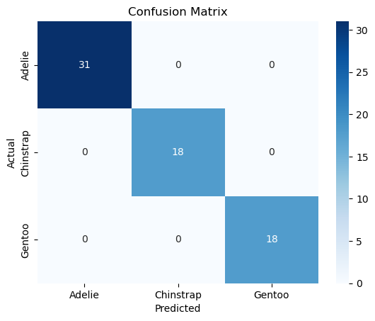

```python
## Step 6 Evaluate the Model

y_pred = model.predict(x_test)  # Make predictions on the test set
accuracy = accuracy_score(y_test, y_pred)  # Calculate accuracy
print(f"Accuracy: {accuracy:.2f}")

print("Classification Report:")
print(classification_report(y_test, y_pred))

print("Confusion Matrix:")
conf_matrix = confusion_matrix(y_test, y_pred)
import seaborn as sns
sns.heatmap(conf_matrix, annot=True, fmt='d', cmap='Blues', xticklabels=model.classes_, yticklabels=model.classes_)
plt.xlabel('Predicted')
plt.ylabel('Actual')
plt.title('Confusion Matrix')
plt.show()
```

```python
## Step 7 Predict New Data
new_data = pd.DataFrame({
    'bill_length_mm': [40, 45],
    'bill_depth_mm': [15, 18],
    'flipper_length_mm': [200, 210],
    'body_mass_g': [5000, 5500]
})

new_predictions = model.predict(new_data)  # Predict the species for new data
print("Predictions for new data:")
for i, pred in enumerate(new_predictions):
    print(f"Sample {i + 1}: {pred}")
```

```
Predictions for new data:
Sample 1: Adelie
Sample 2: Gentoo
```

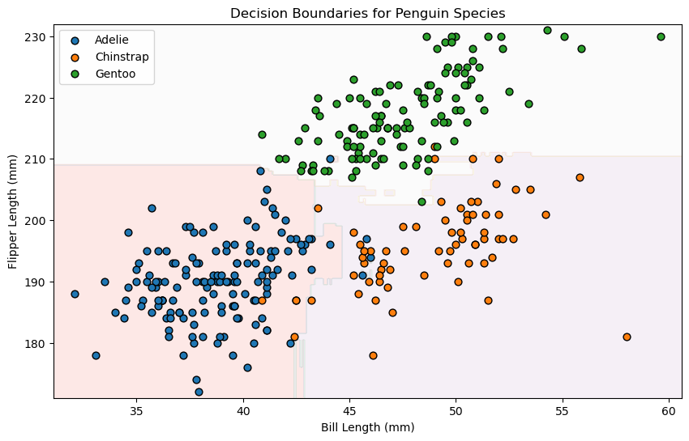

```python
# Use just two features
features = ["bill_length_mm", "flipper_length_mm"]
X = penguins[features]
y = penguins["species"]

# Encode species as numbers for plotting
le = LabelEncoder()
y_encoded = le.fit_transform(y)

# Train/test split
X_train, X_test, y_train, y_test = train_test_split(X, y_encoded, random_state=42)

# Train the model
model = RandomForestClassifier()
model.fit(X_train, y_train)

# Create meshgrid
x_min, x_max = X[features[0]].min() - 1, X[features[0]].max() + 1
y_min, y_max = X[features[1]].min() - 1, X[features[1]].max() + 1
xx, yy = np.meshgrid(np.linspace(x_min, x_max, 300),
                     np.linspace(y_min, y_max, 300))

# Predict over the grid
Z = model.predict(np.c_[xx.ravel(), yy.ravel()])
Z = Z.reshape(xx.shape)

# Plot decision boundary
plt.figure(figsize=(10, 6))
plt.contourf(xx, yy, Z, alpha=0.3, cmap="Pastel1")

# Plot original points, colored by species
for class_index in np.unique(y_encoded):
    label = le.inverse_transform([class_index])[0]
    plt.scatter(X.loc[y_encoded == class_index, features[0]],
                X.loc[y_encoded == class_index, features[1]],
                label=label, edgecolor='k', s=40)

plt.xlabel("Bill Length (mm)")
plt.ylabel("Flipper Length (mm)")
plt.title("Decision Boundaries for Penguin Species")
plt.legend()
plt.show()
```

### Congratulations you've finished up the introduction to python tutorial!

If you're interested in continuing to explore data science, visualizations, or machine learning here are a few follow-up challenges using the Palmer Penguins Datasets:

1. Test whether bill length differs by island - Use a boxplot or group-by comparison. What function could help you compare averages?
2. Try K-Means clustering - What if you didn’t know the species of each penguin? Use `KMeans` from `sklearn` to see if the model can find natural groupings based on the measurements.
3. Visualize feature importance - Which measurements did your model think were most useful for predicting species? Use `.feature_importances_` from your Random Forest model to find out.

You can also explore other biological and ML topics like:

- Principal Component Analysis (PCA) for dimensionality reduction
- Logistic Regression for binary classification
- Classifications with other observations (i.e. iris flowers, fish, disease data)